# DS105-04-06 - ANOVAs - One Way Between Subjects - Activity in R

## Load Libraries

```r
library("dplyr")
library("rcompanion")
library("car")
```

## Load in Data

```r
youtube <- read.csv("./assets/YouTubeChannels.csv")

  # View the data
    head(youtube)
```

|  | Rank | Grade | Channel.name | Video.Uploads | Subscribers | Video.views |
| --- | --- | --- | --- | --- | --- | --- |
| 1 | 1st | A++ | Zee TV | 82757 | 18752951 | 20869786591 |
| 2 | 2nd | A++ | T-Series | 12661 | 61196302 | 47548839843 |
| 3 | 3rd | A++ | Cocomelon - Nursery Rhymes | 373 | 19238251 | 9793305082 |
| 4 | 4th | A++ | SET India | 27323 | 31180559 | 22675948293 |
| 5 | 5th | A++ | WWE | 36756 | 32852346 | 26273668433 |
| 6 | 6th | A++ | Movieclips | 30243 | 17149705 | 16618094724 |

Is there a difference in the **number of views `Video.views`** compared to all the different **grade categories `Grade`**?

`Grade` categories:

```r
sort(unique(youtube$Grade))
```

```
[1] "  "   "A "   "A- "  "A+ "  "A++ " "B+ "
```

## Data Wrangling

No data wrangling needed.

## **Test Assumptions**

### **Assumption: Normality**

Test for the normality of the dependent variable.

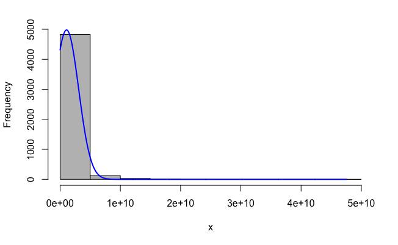

```r
plotNormalHistogram(youtube$Video.views)
```

#### Transform for normality using `Tukey's Ladder of Power`

```r
youtube$Video.viewsTUK <- transformTukey(youtube$Video.views, plotit=FALSE)

plotNormalHistogram(youtube$Video.viewsTUK)
```

[output not shown]

### **Assumption: Homogeneity of Variance**

#### **Bartlett’s Test**

Use the function `bartlett.test()`, with the argument of the `y data` separated by a tilde, followed by the `x data`. `data=` argument is the name of the dataset.

```r
bartlett.test(Video.views ~ Grade, data=youtube)
```

```
    Bartlett test of homogeneity of variances

data:  Video.views by Grade
Bartlett's K-squared = 4513.5, df = 5, p-value < 2.2e-16
```

**Fails assumption of Homogeneity of Variance.**

**`p < .05`**, which means that the data fails the assumption of Homogeneity of Variance.

#### **Computing ANOVAs with Unequal Variance (Violated Homogeneity of Variance Assumption)**

```r
youtubeANOVA <- lm(Video.viewsTUK ~ Grade, data=youtube)
Anova(youtubeANOVA, Type='II', white.adjust=TRUE)
```

```
Coefficient covariances computed by hccm()
```

```
Analysis of Deviance Table (Type II tests)

Response: Video.viewsTUK
            Df      F    Pr(>F)
Grade        5 249.11 < 2.2e-16 ***
Residuals 4994
---
Signif. codes:  0 ‘***’ 0.001 ‘**’ 0.01 ‘*’ 0.05 ‘.’ 0.1 ‘ ’ 1
```

### **Assumption: Sample Size**

*An ANOVA requires a sample size of at least 20 per independent variable.*  
# of independent variables: 1  
required number of cases: 20.

Number of cases: 5000

```r
str(youtube)
```

[output not shown]

**Meets assumption of adequate sample size.**

### **Independence**

There is no statistical test for the assumption of independence.

### **Computing Post Hocs with Unequal Variance (Violated Homogeneity of Variance Assumption)**

```r
pairwise.t.test(youtube$Video.viewsTUK, youtube$Grade, p.adjust="bonferroni", pool.sd = FALSE)
```

```
    Pairwise comparisons using t tests with non-pooled SD

data:  youtube$Video.viewsTUK and youtube$Grade

             A       A-      A+      A++
A    0.0094  -       -       -       -
A-   0.0522  < 2e-16 -       -       -
A+   8.6e-05 7.4e-06 3.1e-11 -       -
A++  5.1e-07 6.4e-05 9.6e-06 0.0019  -
B+   0.2679  < 2e-16 < 2e-16 1.5e-14 3.3e-06

P value adjustment method: bonferroni
```

**The pairwise comparison indicates there is significant difference.**

## **Determine Means and Draw Conclusions**

If there is a significant difference after correction, examine the means to interpret results and draw conclusions.

```r
youtubeMeans <- youtube %>% group_by(Grade) %>% summarize(Mean = mean(Video.views))

youtubeMeans[order(-youtubeMeans$Mean),]
```

| Grade | Mean |
| --- | --- |
| A++ | 21199091193 |
| A+ | 6053120621 |
| A | 2361317332 |
| A- | 1041149249 |
| B+ | 526521651 |
|  | 99120051 |

# Conclusion: